# Where can we install NEVI corridor chargers?

```r
library(readxl)
library(ggplot2)
library(sf)
library(readr)
```

This is a map of the publicly available DC fast chargers across California. Almost all of them fit into the “Corrodor Charger” criteria (Within 1 mile from a highway). The buffer aroud the charger stations indicate a radius of 25 miles diistance. The NEVI formula wants to instal a charging stations every 50 miles.

Notice the gaps in California. The interesting and debatable part comes now. How should we define a “Charger gap”? and estimate where the extra revenue from Prop 30 funds should be deployed (keeping in mind NEVI formula funds will be deployed for the gaps).

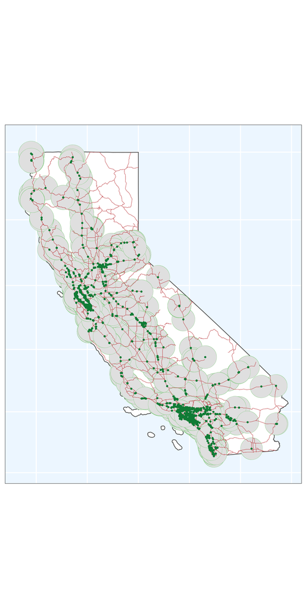

```r
#Map Visualization

plot6 <- ggplot() +
  #geom_sf(data = Boundary,color = "khaki", fill= "white")+
  geom_sf(data = State_Boundary, fill="white")+

  geom_sf(data = buffer2, color= "palegreen3", lwd = 0.1 )+
  #geom_sf(data = buffer, color= "salmon" )+
  geom_sf(data = roads, col="indianred", lwd= 0.2)+
  geom_sf(data = my_sub, color= "springgreen4",size = 1)+

  #geom_sf(data = my_sf, color= "red" )+

  theme_bw()+
  theme(panel.background = element_rect(fill = "aliceblue"),
        axis.ticks = element_blank(),
        axis.text = element_blank(),
        panel.grid = element_line(color = "white", size = 0.8))

plot6
```

The next map is where the grid substations are located across California. The general guidance is to install a station within 2-3 miles of a substation. (The light blue circles are a buffer zone of 3 miles from the substations.)

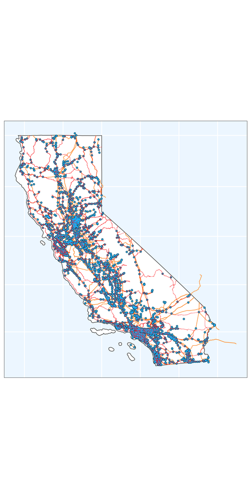

```r
plot8 <- ggplot() +
  geom_sf(data = State_Boundary, fill= "white")+
  geom_sf(data = Transmission, color="tan1") +
  geom_sf(data = Substation_buffer, color="deepskyblue4")+
  geom_sf(data = Substations, color= "deepskyblue", size = 0.3 )+
  geom_sf(data = roads, col="red", lwd= 0.1 )+
  #geom_sf(data = my_sub, color= "springgreen4",size = 0.9)+
  #geom_sf(data = buffer, color= "red" )+


  #geom_sf(data = my_sf, color= "red", size = 0.9 )+
  theme_bw()+
  theme(panel.background = element_rect(fill = "aliceblue"),
        axis.ticks = element_blank(),
        axis.text = element_blank(),
        panel.grid = element_line(color = "white", size = 0.8))

plot8
```

This map combines the two shapefiles. We have possible areas for gaps in the Corridor charger network and locatios with existing substations. We just have to pick a few places so that the State will be convered in Corridor chargers + 25 miles radius map. + Any other installations we want to do for redundancy.

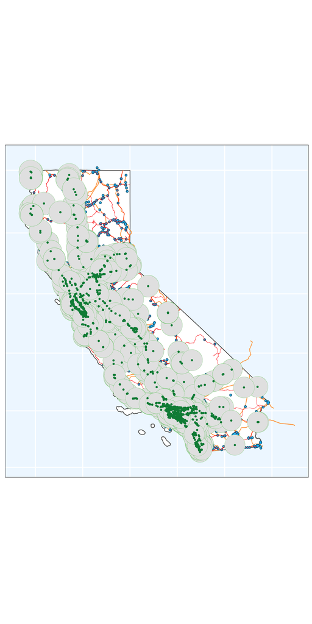

```r
plot8 + geom_sf(data = buffer2, color= "palegreen3", lwd = 0.1 )+
  geom_sf(data = my_sub, color= "springgreen4",size = 1)
```